# data_analysis_2023

drdre

2023-08-17

```r
rm(list = ls())
source("loading_cleaning.R")
source("custom_themes_and_colour_palettes.R")
```

Binning by trial number (experience) rather than 1st or last. better perhaps. To do: - where is control trials going in below code? make sure control data is separate

```r
# removing apis from this analysis
choices <- choices %>% filter(experiment != "thick_oblique_apis")

# Assigning trials to bins and ordering data ####
bin_trials <- function(
    data, bin_size = 15,
    group_vars = c("individual", "experiment", "manipulation")) {
  data %>%
    # all_of throws error if grouping col not found. across allows for 'dynamic eval' of group vars
    group_by(across(all_of(group_vars))) %>%
    mutate(
      trial_bin = ceiling(rank_trial / bin_size),
      trial_range = paste0((trial_bin - 1) * bin_size + 1, "-", trial_bin * bin_size)
    ) %>%
    ungroup()
}

choices <- bin_trials(choices)

# Ensure trial ranges are in sequential order
choices <- choices %>%
  mutate(trial_range = factor(trial_range, levels = unique(trial_range[order(trial_bin)])))

# Calculating prop correct and CIs of bins and ordering ####
source("functions//calc_cis.R")
proportion_data <- calc_cis(
  choices, group_vars = c("experiment", "manipulation", "trial_range", "stimuli"))
```

```
## 'trial_range'. You can override using the `.groups` argument.
```

Plotting

```
## `geom_line()`: Each group consists of only one observation.
## ℹ Do you need to adjust the group aesthetic?
```

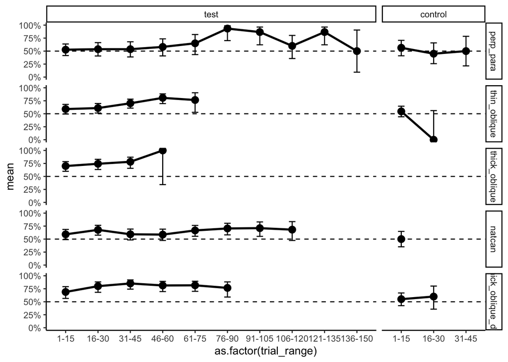

```r
# Arrange order in which experiments appear in facet plot
proportion_data$experiment <- factor(
  proportion_data$experiment,
  levels = c('perp_para', 'thin_oblique', "thick_oblique", "natcan", "thick_oblique_diff",
             "thick_oblique_apis")
)
proportion_data$manipulation <- factor(
  proportion_data$manipulation,
  levels = c('test', 'control', "no_diffuser", "diffuser_bottom", "diffuser_whole"))

# plots: proportion correct/incorrect for different trial bins ####
proportion_data %>%
  ggplot(aes(x = as.factor(trial_range), y = mean, group = experiment)) +
  geom_point(position = position_dodge(0.5), size = 3) +
  geom_line(position = position_dodge(0.5), size = 1) +
  geom_errorbar(aes(ymin = lower, ymax = upper),
                position = position_dodge(0.5), width = 0.2) +
  geom_hline(lty = 2, yintercept = 0.5) +
  scale_y_continuous(labels = scales::percent) +
  theme_classic() +
  theme(legend.position = "none") +
  facet_grid(experiment ~ manipulation, scales = 'free_x', space = "free")
```

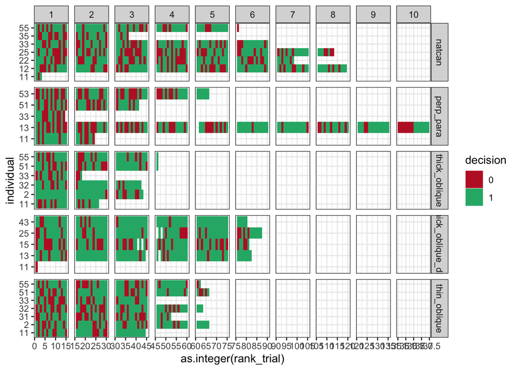

```r
# define different data subsets
proportion_data <- proportion_data %>%
  # removing bins that have low sample size
  filter(total > 10)
proportion_data_test_only <- proportion_data %>%
  filter(manipulation == "test") # only looking at so-called 'test' data

generate_plot <- function(data, same_axis = F) {
  # below ensures Ntrial / Nwasp text doesnt overlap when diff exps plotted on same axis
  if(same_axis == T) {
    data <- data %>%
      group_by(experiment) %>%
      mutate(
        n_wasp_offset = 0.45 - 0.03 * as.numeric(as.factor(experiment)),
        #n_trial_offset = 0.35 - 0.015 * as.numeric(as.factor(experiment))
        ) %>%
      ungroup()
    } else {
  n_wasp_offset = 0.45
  n_trial_offset = 0.4
}

ggplot(data, aes(
    x = as.factor(trial_range), y = mean,
    color = stimuli, group = experiment))+
  geom_point(position = position_dodge(width = 0.3), size = 3)+
  geom_line(position = position_dodge(width = 0.3), size = 1)+
  geom_errorbar(aes(ymin = lower, ymax = upper),
                position = position_dodge(width = 0.3),
                width = 0.2, alpha = 0.3)+
  geom_hline(lty = 2, yintercept = 0.5)+
  geom_text(aes(label = paste0("(", wasp_n, ", ", total,")"),
                y = n_wasp_offset), show.legend = FALSE)+
  #geom_text(aes(label = paste("Nt =", total), y = n_trial_offset))+
  #scale_color_viridis_d(labels = experiment_labels) +
  stim_colour_scale+
  scale_y_continuous(labels = scales::percent)+
  labs(y = "% of choices for reward within trial bin",
       x = "trial")+
  custom_theme_no_x_grid+
  theme(legend.position = "top")
}

p1 <- generate_plot(proportion_data) +
  facet_grid(experiment ~ manipulation, scales = "free_x", space = "free")
p1 <- generate_plot(proportion_data, same_axis = T) +
  facet_grid(cols = vars(manipulation), scales = "free_x", space = "free")
 ggsave("plots//perf_bin_by_bin_for_each_experiment.png",
        plot = last_plot(), width = 9, height = 8, dpi = 300)
# plot the experiments on the same axes to compare prop correct / learning rates
p2 <- generate_plot(proportion_data_test_only, same_axis = T)
# make logistic regression (smoothed) plot combined with bin plot. find code in berlin icn script?

# something weird going on in below plot. due to control issue?
# what are the grey trial blocks from? should be filtered in loading_cleaning?
# Tile plot: individuals' performance across different trial bins
choices %>%
  filter(manipulation == "test") %>%
  ggplot(aes(y = individual, x = as.integer(rank_trial), fill = as.character(decision))) +
  geom_tile() +
  fill_scale +
  facet_grid(experiment ~ trial_bin, scales = "free") +
  theme_bw()
```

Comparing performance among different stimuli in particular subsets (bins by trial) of data Chi sq hypothesis testing and pairwise prop tests for different bins of decisions

```r
# reorder experiment groups from highest prop correct to lowest
subset_df <- choices[choices$manipulation == "test", ]
group_order <- with(subset_df, tapply(as.numeric(decision), stimuli, mean))
group_order <- names(sort(group_order, decreasing = TRUE))
# Reorder group levels based on calculated proportions
choices$stimuli <- factor(choices$stimuli, levels = group_order)
rm(subset_df, group_order)

# desired comparisons
choices_subset <- choices %>%
  #select(-c(9:13)) %>% # why these were dropped im not sure
  filter(manipulation == "test" &
           stimuli %in% c("natcan", 'perp_para',
                          "thin_oblique", "thick_oblique")) %>%
  # combine the relevant bins and create new variable
  mutate(bin_group = case_when(
    trial_bin %in% c(1,2,3) ~ "123",
    #trial_bin %in% c(3,4,5) ~ "345", # why are the bins (123 and 345) overlapping?
    #trial_bin %in% c(6,7,8,9) ~ "6789",
    TRUE ~ "rest")) %>%
  filter(bin_group == "123")

subset_estimates <- calc_cis(choices_subset, c("stimuli", "bin_group"))
```

```r
generate_plot_2 <- function(data){
  # removing thick oblique from the 345 bin, very few obs anyway.
  #filter(! (bin_group == "345" & experiment == "thick_oblique") ) %>%
ggplot(data, aes(x = stimuli, y = mean, color = stimuli, group = stimuli))+
    geom_point(position = position_dodge(width = 0.3), size = 4)+
    geom_errorbar(aes(ymin = lower, ymax = upper),
                position = position_dodge(width = 0.3), width = 0.2)+
    geom_hline(lty = 2, yintercept = 0.5)+
    geom_text(aes(y =0.4, label = paste0("(", wasp_n, ", ", total,")")),
            show.legend = FALSE)+
    stim_colour_scale+
    scale_y_continuous(labels = scales::percent)+
    scale_x_discrete(labels = experiment_labels)+
    labs(y = "% of choices for reward",
       x = "stimuli")+
    custom_theme_no_x_grid+
    theme(legend.position = "none")#+
  #facet_wrap(facets = "bin_group", scales = "free_x", nrow = 1)
}

p <- generate_plot_2(subset_estimates)
 ggsave("plots//perf_across_stimuli_first45_trials.png",
        plot = last_plot(), width = 4, height = 4, dpi = 300)

# pairwise prop and chi sq tests
#bin123 <- choices %>% filter(manipulation == "test", trial_bin %in% c(1,2,3))
bin123 <- table(choices_subset$stimuli, choices_subset$decision,
                exclude = "thick_oblique_apis")

source("functions//pw_prop_test_df_out.R")
chisq.test(bin123)
```

```
##
##  Pearson's Chi-squared test
##
## data:  bin123
## X-squared = 31.228, df = 3, p-value = 7.611e-07
```

```r
pw_results_bin123 <- pw_prop_test_df_out(bin123, p_adjust_method = "holm")
```

Do dorsal stimuli provide snapshot information? Comparing test props / perf to controls  
and to the 50% line

```r
test_vs_ctrl <- calc_cis(choices, group_vars = c("stimuli", "manipulation"))
```

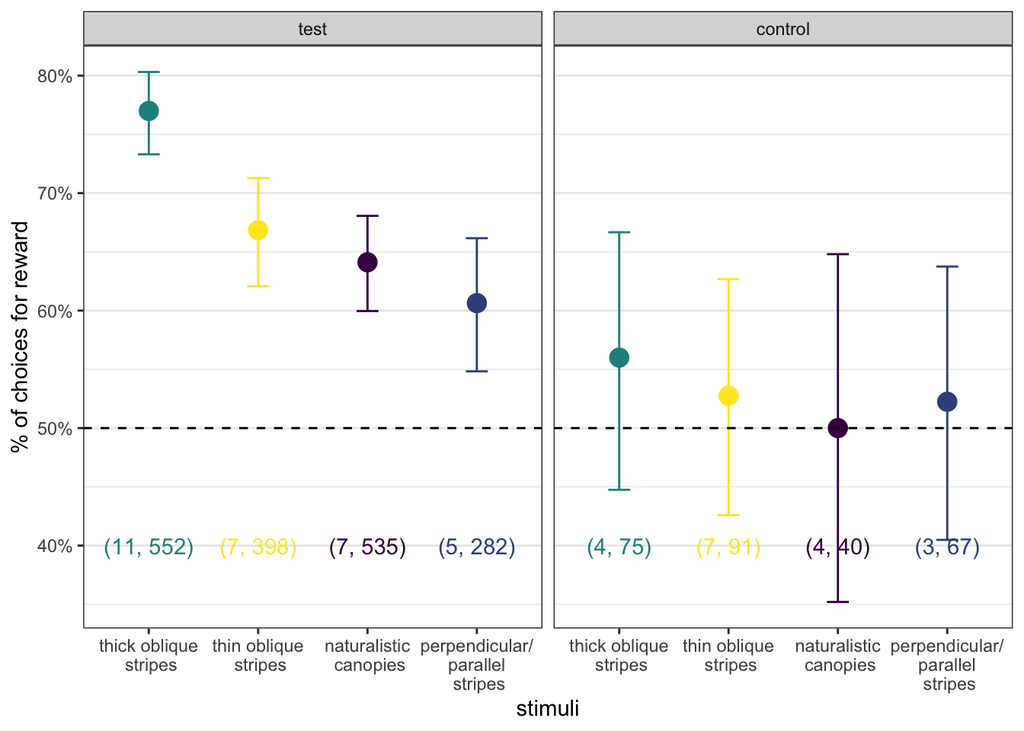

```r
test_vs_ctrl$manipulation <- fct_relevel(test_vs_ctrl$manipulation, "test")

generate_plot_2(test_vs_ctrl)+facet_grid(cols = vars(manipulation))
```

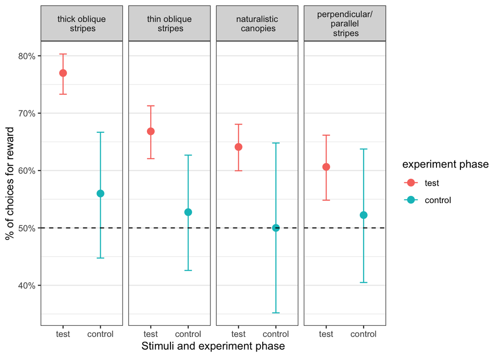

```r
all_bins <- table(choices$manipulation, choices$decision, choices$stimuli)
#                exclude = "thick_oblique_apis")
ggplot(test_vs_ctrl, aes(x = manipulation, y = mean, color = manipulation)) +
  geom_point(position = position_dodge(width = 0.6), size = 3) +
  geom_errorbar(aes(ymin = lower, ymax = upper),
                position = position_dodge(width = 0.6), width = 0.2)+
  geom_hline(lty = 2, yintercept = 0.5)+
  scale_y_continuous(labels = scales::percent)+
  labs(x = "Stimuli and experiment phase", y = "% of choices for reward", color = "experiment phase")+
  facet_grid(cols = vars(stimuli), scales = "free_x",
             labeller = as_labeller(experiment_labels))+
  custom_theme_no_x_grid
```

```r
 ggsave("plots//perf_test_vs_control_all_trials2.png",
        plot = last_plot(), width = 7, height = 4, dpi = 300)

test_vs_control_results <- apply(all_bins, 3, prop.test)

test_vs_control_results <- do.call(
  rbind, lapply(test_vs_control_results, function(res) {
    data.frame(
      p_value = res$p.value,
      estimate_diff = res$estimate[1] - res$estimate[2],
      conf_low = res$conf.int[1],
      conf_high = res$conf.int[2]
    )
}))

test_vs_control_results$p_value <- p.adjust(
  test_vs_control_results$p_value, method = "holm")

test_vs_control_results$comparison <- paste0(rownames(test_vs_control_results),
                                             " test vs control")

# test vs chance 50% line
all_bins <- table(choices$stimuli, choices$decision, choices$manipulation)
x <- all_bins[,"1","test"]
n <- apply(all_bins[,,"test"], 1, sum)

results <- mapply(function(success, total) {
  prop.test(success, total)
}, x, n, SIMPLIFY = FALSE)

test_vs_50pcent_results <- do.call(
  rbind, lapply(results, function(res) {
    data.frame(
      p_value = res$p.value,
      estimate = res$estimate,
      conf_low = res$conf.int[1],
      conf_high = res$conf.int[2]
    ) %>%
      mutate(
        across(c(estimate, conf_low, conf_high),
               ~ . - 0.5, .names = "{.col}_50pcent")
  )
}))

test_vs_50pcent_results$p_value <- p.adjust(
  test_vs_50pcent_results$p_value, method = "holm")

test_vs_50pcent_results$comparison <- paste0(rownames(test_vs_50pcent_results),
                                             " test vs control")
```

Table formatting

```r
#library(gt)
library(sjPlot)
format_p_values <- function(p) {
  ifelse(p < 0.001, "<0.001",  formatC(p, format = "f", digits = 3))
}
# text substitutions:
text_subs <- c("diff" = "diffuser", "natcan" = "naturalistic canopy",
               "perp_para" = "perpendicular-parallel", "_" = " ")
pw_results_bin123 <- pw_results_bin123 %>%
  mutate(
    groups = str_replace_all(groups, text_subs),
  # convert diffs in prop to diffs in %
    across(c(estimate_diff, conf_low, conf_high), ~ round(.x, 3)),
    across(c(estimate_diff, conf_low, conf_high), ~ .x *100),
    `95 % confidence interval` = paste0("[", conf_low, "; ", conf_high, "]"),
    p_value = format_p_values(p_value)
  ) %>%
  select(-conf_low, -conf_high)

# rename table headings
pw_results_bin123 <- pw_results_bin123 %>%
   rename(`stimuli compared` = groups,
          `p value` = p_value,
           `difference in % correct choices (group 1 - group 2)`= estimate_diff)
sjPlot::tab_df(pw_results_bin123,
               file = "tables//pw_prop_test_results_trial_0_to_45.html")
```

| stimuli.compared | p.value | difference.in…correct.choices..group.1…group.2. | X95…confidence.interval |
| --- | --- | --- | --- |
| thick oblique vs thin oblique | 0.002 | 12.20 | [5.1; 19.3] |
| thick oblique vs naturalistic canopy | 0.001 | 13.40 | [5.9; 21] |
| thick oblique vs perpendicular-parallel | <0.001 | 22.30 | [13.3; 31.3] |
| thin oblique vs naturalistic canopy | 0.822 | 1.30 | [-7; 9.5] |
| thin oblique vs perpendicular-parallel | 0.116 | 10.10 | [0.4; 19.8] |
| naturalistic canopy vs perpendicular-parallel | 0.168 | 8.90 | [-1.1; 18.9] |

```r
# convert the str replace instances above to a mapping that can be reused for this table.
# consider moving all table formatting to a new script.
test_vs_control_results <- test_vs_control_results %>%
    mutate(
      comparison = str_replace_all(comparison, text_subs),
      across(c(estimate_diff, conf_low, conf_high), ~ round(.x, 3)),
      across(c(estimate_diff, conf_low, conf_high), ~ .x *100),
      `95 % confidence interval` = paste0("[", conf_low, "; ", conf_high, "]"),
      p_value = format_p_values(p_value)
  ) %>%
  select(-conf_low, -conf_high) %>%
  relocate(comparison, .before = everything())
sjPlot::tab_df(test_vs_control_results,
               file = "tables//test_vs_control_results.html")
```

| comparison | p_value | estimate_diff | X95…confidence.interval |
| --- | --- | --- | --- |
| thick oblique test vs control | <0.001 | 21.00 | [8.5; 33.5] |
| thin oblique test vs control | 0.048 | 14.10 | [2.2; 26] |
| naturalistic canopy test vs control | 0.213 | 14.10 | [-3.3; 31.5] |
| perpendicular-parallel test vs control | 0.263 | 8.40 | [-5.8; 22.6] |

```r
# convert the str replace instances above to a mapping that can be reused for this table.
# consider moving all table formatting to a new script.
test_vs_50pcent_results <- test_vs_50pcent_results %>%
    mutate(
      p_value = format_p_values(p_value),
      comparison = str_replace_all(comparison, text_subs),
      across(matches("estimate|conf_low|conf_high"), ~ round(.x, 3)),
      across(matches("estimate|conf_low|conf_high"), ~ .x *100),
      `95 % confidence interval` = paste0("[", conf_low, "; ", conf_high, "]"),
      `95 % confidence interval of difference` =
        paste0("[", conf_low_50pcent, "; ", conf_high_50pcent, "]")
  ) %>%
  select(-conf_low, -conf_high, -conf_low_50pcent, -conf_high_50pcent) %>%
  relocate(comparison, .before = everything())
sjPlot::tab_df(test_vs_control_results,
               file = "tables//test_vs_50pcent_results.html")
```

| comparison | p_value | estimate_diff | X95…confidence.interval |
| --- | --- | --- | --- |
| thick oblique test vs control | <0.001 | 21.00 | [8.5; 33.5] |
| thin oblique test vs control | 0.048 | 14.10 | [2.2; 26] |
| naturalistic canopy test vs control | 0.213 | 14.10 | [-3.3; 31.5] |
| perpendicular-parallel test vs control | 0.263 | 8.40 | [-5.8; 22.6] |

Looking at the effect of day on choices would be nice if this effect could be visualized in the same plot as the main one above

```r
# we group by day as well so trial bins start anew each day
choices <- bin_trials(
  choices, bin_size = 10,
  group_vars = c("individual", "experiment", "manipulation", "day"))

# need to run this code again (put in function?) to recalculate conf.ints etc.
# Calculating prop correct and CIs of bins and ordering ####
proportion_data <- choices %>%
  group_by(experiment, manipulation, trial_bin, trial_range,
           day) %>% # must also group by day in order to keep the variable
  summarise(
    wasp_n = n_distinct(individual),
    count_1 = sum(decision == 1),
    count_0 = sum(decision == 0),
    total = sum(count_1, count_0)) %>%
  rowwise() %>%
  mutate(tst = list(binom::binom.confint(count_1, total, method = "wilson"))) %>%
  unnest(tst) %>%
  ungroup()

# define different data subsets
proportion_data <- proportion_data %>%
  filter(decision == "1", total > 5) # removing bins that have low sample size
proportion_data_test_only <- proportion_data %>%
  filter(manipulation == "test") # only looking at so-called 'test' data

p2 <- generate_plot(proportion_data_test_only, same_axis = T)
p2+facet_wrap(vars(day), nrow = 1, scales = "free_x")

x <- proportion_data_test_only %>%
  filter(experiment == "thick_oblique_diff" & day == "3")
x <- choices %>%
  filter(experiment == "thick_oblique_diff" & day == "3")
```

logistic regression of performance across trials

```r
# I only want to compare the curves of thick +-45 vs thin +-45 vs 0 / 90 during TESTING types
# to do that I'll make a new variable where control is excluded from thin_oblique testing

choices_test <- choices[choices$experiment_type != 'control',]
# run log reg and plot again:
fit <- glm(first ~ rank_trial * factor(experiment), data = choices_test, family = binomial)
summary(fit)
choices_test$predicted_probabilities <- predict(fit, type = "response")

comp_points <- choices_test %>% filter(rank_trial == "46")

ggplot(data = choices_test,
       aes(x = rank_trial, y = predicted_probabilities,
           color = as.factor(experiment), fill = as.factor(experiment)))+
  geom_smooth(method = "glm", method.args = list(family = binomial), alpha = 0.5)+
  geom_point(data = comp_points,
             aes(x = rank_trial, y = predicted_probabilities),
             size = 4.5, stroke = 1.5, shape = 21, color = "black")+
  labs(x = "Trial", y = "% of decisions for reward")+
  scale_y_continuous(labels = scales::percent)+
  scale_colour_viridis_d()+
  scale_fill_viridis_d()+
  scale_x_continuous(breaks = c(0,46,50, 100), labels =  c("0","", "50", "100"))+
  #  scale_color_brewer(type = "qual", palette = "Set3")+
  geom_hline(yintercept = 0.5, lty = 2, size = 1.5)+
  custom_theme_text_enlarged+
  theme(legend.position = "none",
        #panel.border = element_rect(
        #linetype = "solid", colour = "black", size=5, fill = NA),
        axis.line = element_line(colour = 'black', size = 1.5),
        axis.ticks = element_line(colour = "black", size = 1.5),
        axis.ticks.length=unit(.3, "cm"),
        plot.margin = margin(15,1,5,1),
        #axis.text.x=element_blank(),
        #axis.ticks.x=element_blank()
        )
ggsave("//Users//andrescheepers//Desktop//berlin_ICN_poster//exp_comp_lineplot_perf_across_trials.png", plot = last_plot(),
       width = 10, height = 6.5, dpi =300)
# How do we interpret these stats?
# ggsave("figures//optflow_log_reg_thin_oblique.png", plot = last_plot(), width = 5, height = 3, dpi = 300)

# comparing means of groups at a particular value of trial number:
# Load necessary libraries
library(emmeans)
library(multcomp)
library(multcompView)

# Fit the logistic regression model with interaction
model <- glm(first ~ experiment * rank_trial, data = choices_test, family = binomial)
summary(model)

# Calculate adjusted predicted probabilities for a specific value of the covariate (e.g., the mean value)
max_covariate_thick_obl <- max(choices_test[choices_test$experiment == "thick_oblique",]$rank_trial)
emm <- emmeans(model, ~ experiment | rank_trial,
               at = list(rank_trial = max_covariate_thick_obl), type = "response")
print(emm)
plot(emm, comparisons = TRUE)

# Perform pairwise comparisons
pairs <- pairs(emm, adjust = "tukey")
print(pairs)

# Get compact letter display for significant differences
cld <- cld(emm, adjust = "tukey", Letters = letters, type = "response")
print(cld)

# Convert results to data frames
emm_df <- as.data.frame(emm)
cld_df <- as.data.frame(cld)

# Inspect the structure of the data frames to identify correct column names
str(emm_df)
str(cld_df)


# Plotting the results with correct column names
ggplot(emm_df, aes(x = experiment, y = prob,
                   fill = experiment, color = experiment))+
  geom_point(stat = "identity", shape = 21,
             position = position_dodge(width = 0.9),
           color = "black", size = 4.5, stroke = 1.5)+
  geom_errorbar(aes(ymin = prob - SE, ymax = prob + SE),
                width = 0.2, position = position_dodge(width = 0.9)) +
  geom_text(data = cld_df,
            aes(x = experiment, y = prob + 0.07, label = .group),
            color = "black", size = 10,
            position = position_dodge2(width = 1, padding = 100)) +
  labs(x = "Stimulus pair",
       y = "Predicted % choices for reward")+
  geom_hline(yintercept = 0.5, lty = 2, size = 1.5)+
  #scale_fill_brewer(type = "qual", palette = "Set3")+
  scale_fill_viridis_d()+
  scale_color_viridis_d()+
  scale_y_continuous(labels=scales::percent)+
  scale_x_discrete(
  limits = c("nat_can", "perp_para", "thin_oblique", "thick_oblique"),
  labels = c("Naturalistic", "0, 90", "thin +45, -45", "thick +45, -45"))+
  custom_theme_text_enlarged+
    theme(legend.position = "none",
        #panel.border = element_rect(
          #linetype = "solid", colour = "black", size=5, fill = NA),
        axis.line = element_line(colour = 'black', size = 1.5),
        axis.ticks = element_line(colour = "black", size = 1.5),
        axis.ticks.length=unit(.3, "cm"),
        plot.margin = margin(15,1,5,1),
        axis.text.x = element_text(angle = 20, size = 20, vjust = 0.9, hjust = 0.8),
        #axis.ticks.x=element_blank()
        )
ggsave(
  "//Users//andrescheepers//Desktop//berlin_ICN_poster//exp_comp_barplot_perf_across_experiments_after_46_trials.png",
       plot = last_plot(),
       width = 9, height = 6.5, dpi =300)
```

```r
test_vs_50pcent_results[1,6]
```

```
## [1] "[23.2; 30.4]"
```

```r
pw_results_bin123[pw_results_bin123$`stimuli compared` == "thin oblique vs perpendicular-parallel",]
```

```
##                               stimuli compared p value
## prop 14 thin oblique vs perpendicular-parallel   0.116
##         difference in % correct choices (group 1 - group 2)
## prop 14                                                10.1
##         95 % confidence interval
## prop 14              [0.4; 19.8]
```

```r
pw_results_bin123[,1]
```

```
## [1] "thick oblique vs thin oblique"
## [2] "thick oblique vs naturalistic canopy"
## [3] "thick oblique vs perpendicular-parallel"
## [4] "thin oblique vs naturalistic canopy"
## [5] "thin oblique vs perpendicular-parallel"
## [6] "naturalistic canopy vs perpendicular-parallel"
```

Results manuscript write up: question 1: Can wasps use dorsal landmark information? And can they use ‘naturalistic canopies’ ?

The percentage of correct decisions are also significantly higher [9.9; 18.2] than 50% for the naturalistic canopy stimuli.

Question 2: Are there differences in the performance among stimuli? - Specifically, are there differences in performance between the thin oblique stripes and the parallel-perpendicular stimuli?

However, the larger proportion correct for the thin oblique stimuli might not hold if performance is compared to perpendicular parallel in later trials (Figure x). (could also use a logistic regression comparison here, look at ICN Berlin plot and code).

Discussion points: - comparing stimuli at peak even though there are diff numbers of trials. - perp parallel eventually reaches same peak as thin oblique (though with much lower conf), but why does it take much longer? is this the idiosyncracy of a single individual? But low indiv sample size wouldnt explain why it takes so long to peak in initial phase of experiment. Perhaps this experiment needs to be redone, as experimental differences in training or testing phases might explain.

## Things to think about

What is the effect of the blocking I’ve been doing? I haven’t had a very firm or consistant rule about blocking except that I do it after an individual makes consistant mistakes in one direction and appears to have a side bias. I think its important to think about because its a very effective way to teach the wasp or to accelerate its learning. I use blocking with the intention of showing the wasp that it can turn the other direction and still receive the reward. I believe that insects might need to learn to override a consistant motor command, or perhaps to learn that varying the motor commands is more effective (more rewarding) than using one motor command exclusively. I think that the wasp might need to be shown that two paths exist and that one path always contains the reward. If the wasp is not shown this, then all it knows is that it is receiving rewards in a somewhat idiosyncratic way. Perhaps the wasp does ‘notice’ that the pattern overhead signifies the presence of reward or the lack thereof. But it surely doesn’t know that the reward exists in the other arm when it is not present in this arm. How could it? Unless it has some in-built mechanism that informs steering commands when a snapshot is not matched. This makes me wonder, what happens if you just have one arm and change the patterns and reward? Will the wasp ever learn to turn around, or increase its turning around over time? Or can this only happen when the wasp also learns that there is another location to turn around and go to?

If the wasp learns that there are two locations, does this heighten its sensitivity to the differences in the two dorsal patterns? I’m wondering if when there is only one arm / location the wasp is less sensitive to changes in the pattern because these changes can and do happen in nature.

- I should account for side bias in my analyses. One effect of side bias in combination with an unequal number of trials will be an over / underestimate of decision accuracy. How can I account for too many trials on one side? I need to weight the trials from each side equally…
- there are important decisions to make around which individuals to include seeing as some came into experiments at different times and may have had side preferences for longer. Im thinking #31 from recent experiments where I had too many individuals to give it proper attention and eradicate its side preference rapidly. One solution may be to analyze results with different subsets of individuals and to see whether it affects inferences.
- I wonder if its not just the accuracy of first decisions that changes when you chang from patterns to no patterns but also the total number of incorrect decisions? ie do they go the same, wrong way a lot more when no patterns in? What does this mean?
- humans can probably learn thousands of faces, insects can probably learn thousands of snapshots. can I learn anything from the human face recognition literature?
- i wouldnt jump to the conclusion that many thin stripes is more difficult than thick stripes just from this data because thick stripes had a training session not included in the data, which could bias the proportion correct upwards.
- is it really true that insects get better across trials? or is this just an effect of averaging across insects and rather there is a distinct moment that each insect ‘gets it’? Would an interaction between trial and individual perhaps account for this? I haven’t thought much about what the different models would be testing.

TO DO: 0. enter data and plot previous experiments. particularly interested in seeing the first control. make note of the fact that training procedures have changed… 1. make tile plot for the cohort across thick stripe, multi small stripe and control. would be nice to annotate the onset of different days and experiments.

INF. revisit logistic regression basics to understand the stats.

INF. visualize proportion correct of thick stripe, mulitple small stripes, and control. next, think about logistic regression and learning rates.

INF. change name of ‘choices’ to reflect the experiment. eg. angled is a better name. If i’m still separating datasets by experiment.